# Matt Melnychuk’s Midterm for R 421

#### Cost per day by hospital B (15B):

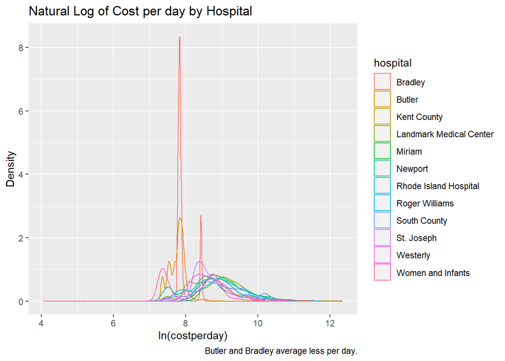

```r
df2$lncpd <- log(df2$costperday)
df2 %>% filter(costperday>0) %>%ggplot()+
  geom_density(mapping = aes(x = lncpd, color = hospital)) + labs(title = 'Natural Log of Cost per day by Hospital', x='ln(costperday)', y='Density', fill='Hospital', caption = 'Butler and Bradley average less per day.')
```

#### Cost per day by hospital C (15C):

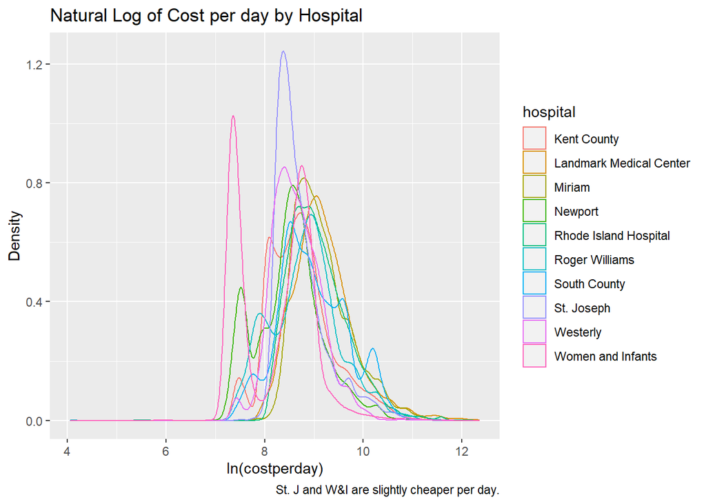

```r
df2$lncpd <- log(df2$costperday)
df2 %>% filter(costperday>0) %>% filter(hospital !='Bradley') %>% filter(hospital !='Butler') %>%ggplot()+
  geom_density(mapping = aes(x = lncpd, color = hospital)) + labs(title = 'Natural Log of Cost per day by Hospital', x='ln(costperday)', y='Density', fill='Hospital', caption = 'St. J and W&I are slightly cheaper per day.')
```

Originally, the scale made it difficult to interpret this graph. Next, Bradley and Butler were removed because they also made the graph difficult to interpret since they charge much less per day than other hospitals. Finally, it appears that St. Josephs and Women and Infants charge slightly less per day than other providers in Rhode Island.

#### Cost by admittance type (16):

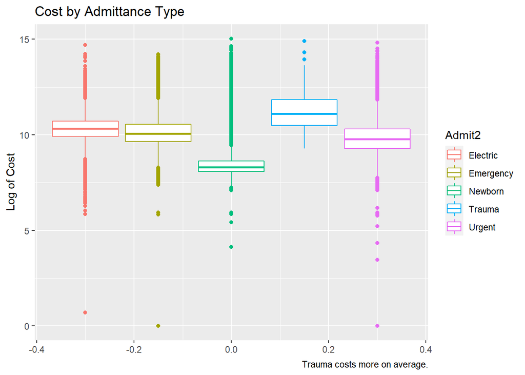

```r
df2  %>% filter(Admit2 != '') %>% filter(Admit2 != 'Unknown') %>% ggplot()+ geom_boxplot(mapping = aes(y = log(tot), color = Admit2)) + labs(title = 'Cost by Admittance Type', y='Log of Cost', fill='Admittance Type', caption = 'Trauma costs more on average.')
```

Trauma costs more on average than any of the other reasons for admition to the hospital. Also, newborns are cheaper than any other reason for visiting the hospital.

#### Cost per day by Admittance type (16B):

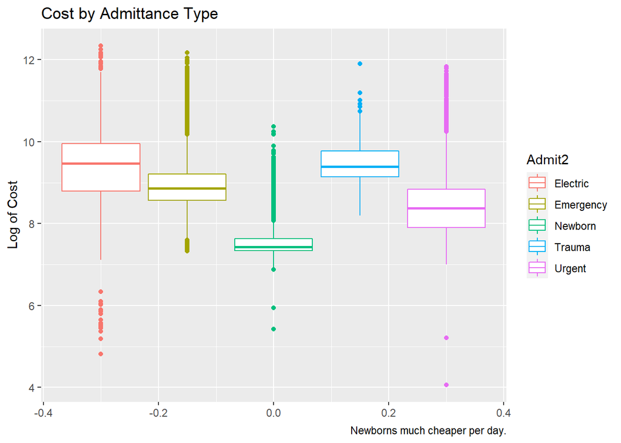

```r
df2  %>% filter(Admit2 != '') %>% filter(Admit2 != 'Unknown') %>% ggplot()+ geom_boxplot(mapping = aes(y = log(costperday), color = Admit2)) + labs(title = 'Cost by Admittance Type', y='Log of Cost', fill='Admittance Type', caption = 'Newborns much cheaper per day.')
```

Newborns cost much less per day than any other reason for visiting the hospital. Trauma now appears to be in line with other reasons for visiting when looking at cost per day instead of just total cost, which means that trauma patients may just be in the hospital for longer periods of time.

2. Make an animation plot.

### Animated Bar Race - Births by Hospital (18):

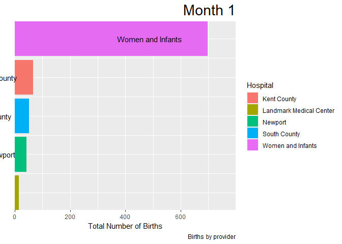

```r
d1 <- df2 %>% filter(Admit2 == 'Newborn') %>% group_by(hospital, moa) %>% summarise(births = n())
d2 <- d1 %>% group_by(moa) %>% mutate(rank=rank(-births)) %>% ungroup()
a1 <- d2 %>% ggplot(aes(x=rank, y=births, group=hospital, fill=hospital, label=hospital)) + geom_col()+
    geom_text(aes(y = births, label = hospital), hjust = 1.4)+
    coord_flip(clip = "off", expand = FALSE) +scale_x_reverse()+
    labs(title = 'Month {closest_state}', x='', y='Total Number of Births', fill='Hospital', caption = 'Births by provider')+
    theme(plot.title = element_text(hjust = 1, size = 22),
          axis.ticks.y = element_blank(),
          axis.text.y  = element_blank()) +
    transition_states(moa)+
    ease_aes("cubic-in-out")
library(gifski)
animate(a1, renderer = gifski_renderer())
```

Women and Infants consistently has the most births. I will run this same graphic again without that hospital since it throws off the scale so much.

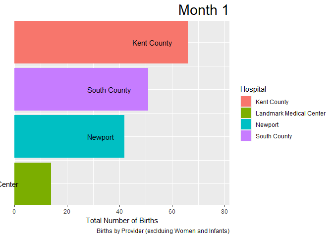

```r
d1 <- df2 %>% filter(Admit2 == 'Newborn',hospital!='Women and Infants') %>% group_by(hospital, moa) %>% summarise(births = n())
d2 <- d1 %>% group_by(moa) %>% mutate(rank=rank(-births)) %>% ungroup()
a1 <- d2 %>% ggplot(aes(x=rank, y=births, group=hospital, fill=hospital, label=hospital)) + geom_col()+
    geom_text(aes(y = births, label = hospital), hjust = 1.4)+
    coord_flip(clip = "off", expand = FALSE) +scale_x_reverse()+
    labs(title = 'Month {closest_state}', x='', y='Total Number of Births', fill='Hospital', caption = 'Births by Provider (exclduing Women and Infants)')+
    theme(plot.title = element_text(hjust = 1, size = 22),
          axis.ticks.y = element_blank(),
          axis.text.y  = element_blank()) +
    transition_states(moa)+
    ease_aes("cubic-in-out")
library(gifski)
animate(a1, renderer = gifski_renderer())
```

There are four other hospitals in Rhode Island where babies were born during 2018. Kent County Hospital normally has more births than South County Hospital, but they do briefly change rank in February and March. It is possible that babies are born in these other hospitals because the mothers may be located far away from Providence and choose to go to a closer hospital instead.

3. Write a paragraph to summarize the section and give your comments on the results.

In general, some hospitals specialize while others do not. For example, the average patient age is much younger at Bradley, Women and Infants, and the Hasbro branch of RI Hospital. Bradley and Butler also have more *urgent* visits compared to *emergency* visits at other providers, possibly because these two centers are focused more on psychological well-being and mental health than solely physical health. Also, it appears that the longest ICU stays take place at Kent County.

The length of time a patient spends in the hospital is very right skewed. It was determined that age and race have no impact on how long someone spends in the hospital. Bradley and Butler typically have patients stay for longer periods of time, which often means that patients here have larger bills.

Bradley is the most expensive hospital in terms of total bill by a large margin, followed by Rhode Island hospital in second. Middle-aged patients typically have slightly larger bills than young or elderly patients (as demonstrated by the parabolic curves), but it is important to note that price by age is the exact opposite for Butler. Race has little impact on total cost over the first 100 days, and it is possible that the supposed impact it plays on the bill for longer shifts is due to a small amount of data.

In general, cost is right skewed, and it may make more sense to examine cost per day in determining which hospital is the cheapest or most expensive. In terms of cost per day, Bradley and Butler are the cheapest (possibly due to having such long-term residents), with Women and Infants and St. Josephs hospital being the next cheapest. Also, trauma typically is more expensive than other reasons for admittance, but on a daily basis it is more in-line with other reasons for admittance. Newborns cost less than other reasons both on a total basis and on a daily basis. Based on the revealing line plot, Rhode Island hospital consistently brings in the most revenue, and revenue appears to be very consistent month to month with no apparent seasonal pattern.

When looking at birth weights, race and sex have no impact, nor does the month of birth. In general, babies born at Women and Infants are slightly smaller than average, and Women and Infants handles the majority of births in the state by a large margin as demonstrated by the animated bar race.

## III. Predictive Models

Continue with the data from part I. Use the following as the target and input variables:

*Target Variable*: Create the target variable taking value of

- `low` if the total charge of a patient (`tot`) is smaller than the median of the total charge, and
- `high` otherwise.

```r
median(df2$tot)
```

```
## [1] 21854
```

```r
df2$target <- case_when(
  df2$tot < 21854 ~ 'low',
  df2$tot >= 21854 ~'high',
  TRUE ~ 'high')
```

*Input Variables*:

- “age”,“sex”,“raceethn”,“provider”,“moa”,“mod”,“admtype”,“campus”, ‘los’
1. Use `filter` function to filter out rows where `raceethn==''` or `admtype==''`. Make sure all the categorical variables are factor, numeric variables are numeric. Set Training : Testing Split = 10 : 90.

*Notice:* I will be using 10% of the data as a test and 90% of the data to train (it does not make sense to split 90% in testing or only 10% in training).

```r
library(tidyverse)
df3 <- df2 %>% filter(raceethn!='') %>% filter(admtype!='')
df3 <- select(df3, c("age","sex","raceethn","provider", "moa","mod","campus", 'los','target','admtype'))

#categorical variables
df3$sex <- as.factor(df3$sex)
df3$raceethn <- as.factor(df3$raceethn)
df3$provider <- as.factor(df3$provider)
df3$moa <- as.factor(df3$moa)
df3$mod <- as.factor(df3$mod)
df3$campus <- as.factor(df3$campus)
df3$target <- as.factor(df3$target)
df3$admtype <-as.factor(df3$admtype)

#continuous variables
df3$los <- as.numeric(df3$los)
df3$age <- as.numeric(df3$age)

library(caret)
set.seed(2020)
splitIndex <- createDataPartition(df3$target, p = .90,
                                  list = FALSE)
df3_train <- df3[ splitIndex,]
df3_test <- df3[-splitIndex,]
```

2. Train a decision tree using `rpart`. Plot the decision tree.

[figure not shown]

```r
library(rpart)
set.seed(2020)
tree_model <- rpart(target ~ ., data = df3_train,
                 control = rpart.control(maxdepth = 4))

# Plot the results
library(rattle)
fancyRpartPlot(tree_model)
```

The first split involves `length of stay`, and it makes sense that length of stay helps to determine if a cost is expensive (longer stays usually lead to more expensive bills). After that, it seems that different `providers` may be cheaper or more expensive, which also makes sense in constructing a decision tree. Also, `type of admission` is a split which can help determine cost. This makes sense because Trauma (`5`) may lead to higher costs in shorter stays than something like a newborn.

2b. Plot the variable importance ranked by the tree.

```r
tree_model$variable.importance
```

```
##          los      admtype     provider          age       campus     raceethn
## 15426.369067  4286.092280  3356.432698  1891.880388   804.241220   125.527008
##          sex
##     1.085693
```

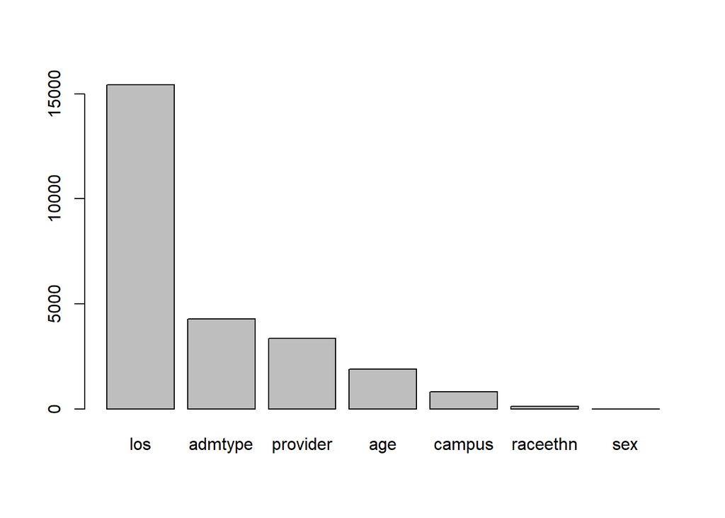

```r
barplot(tree_model$variable.importance)
```

`Length of stay` is the most important variable in predicting if there will be a high cost. The next most important variables are `type of admittance` and `provider`, which makes sense because some hospitals may be more expensive and some procedures/reasons for being at the hospital are much more expensive than others.

3. Using caret for this question. Set `Training Control` to be: Use Cross-Validation of 5 folds across all models. Train & tune at least 3 different models (i.e. three different values for `method=` in the train function of caret). Plot the hyper-parameter tuning plots for each model.

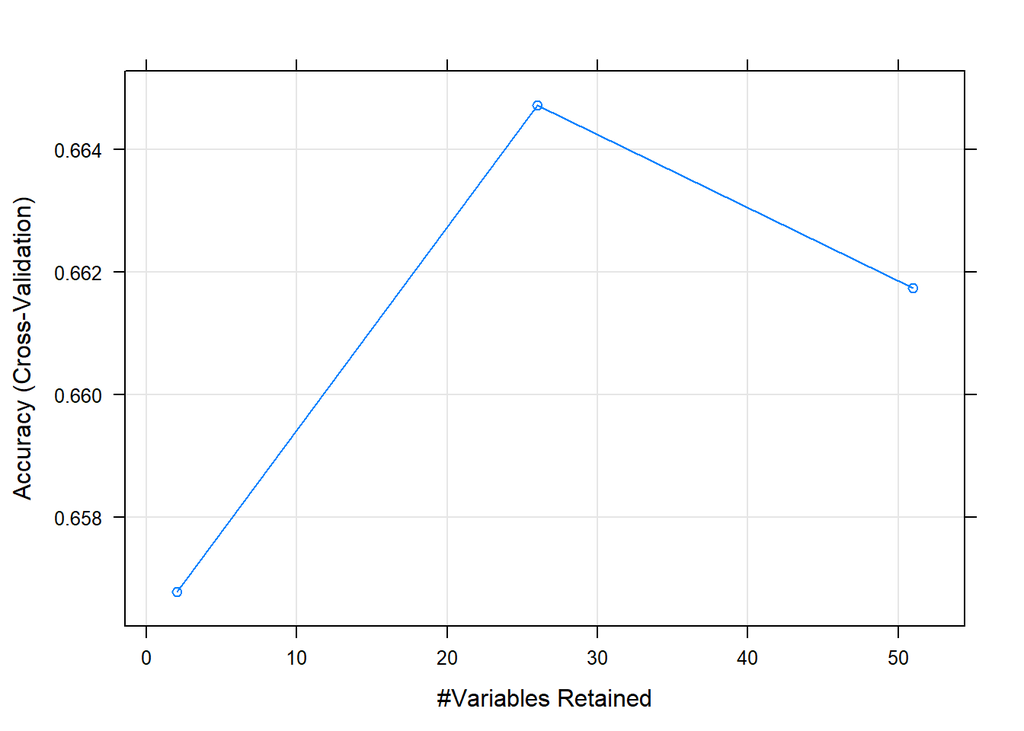

```r
set.seed(2020)
df3small <- sample_n(df3,13000)
library(caret)
set.seed(2020)
splitIndex <- createDataPartition(df3small$target, p = .90,
                                  list = FALSE)
df3_train <- df3small[ splitIndex,]
df3_test <- df3small[-splitIndex,]

trControl = trainControl(method = "cv",
                         number = 5)

model1 <- train(target~., data=df3_train,
                                method = "rocc",
                                trControl = trControl)
plot(model1)
```

```r
model2 <- train(target~., data=df3_train,
                    method = "pam",
                                trControl = trControl)
```

```
## 123456789101112131415161718192021222324252627282930111111
```

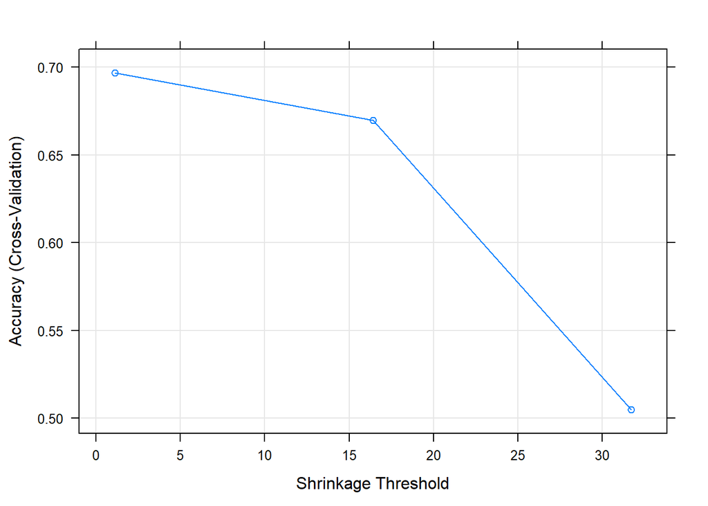

```r
plot(model2)
```

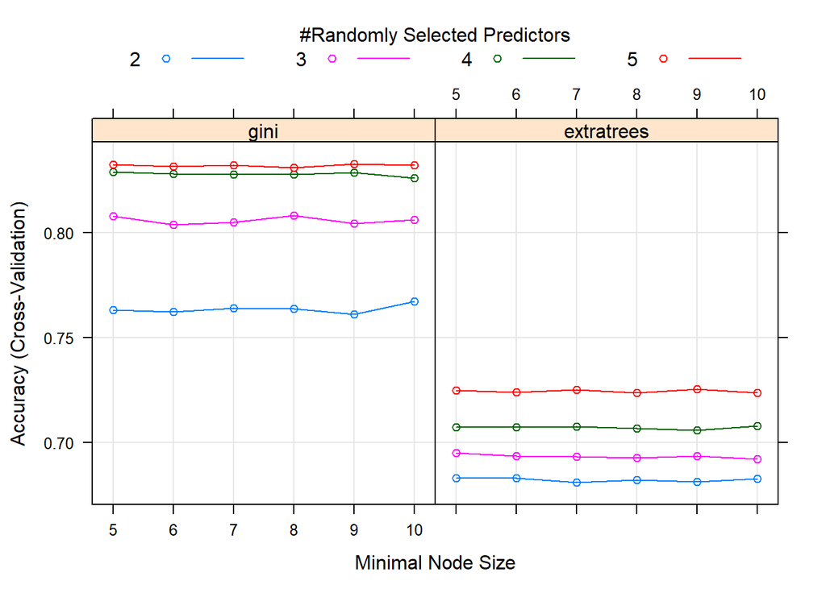

```r
tuneGrid = expand.grid(mtry = 2:5,
                       splitrule = c('gini', 'extratrees'),
                       min.node.size = c(5:10))
set.seed(2020)
model3 <- train(target~., data=df3_train,
                    method = "ranger",
                    trControl = trControl,
                    tuneGrid = tuneGrid)
plot(model3)
```

It appears more predictors leads to better models, and the gini split is better than the extra trees split.

4. Plot the comparison of the models in 3.

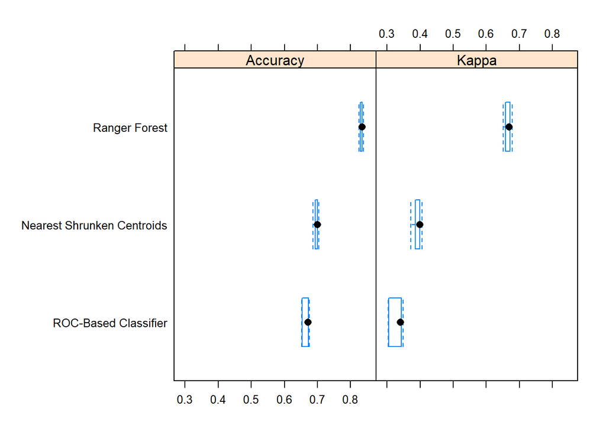

```r
results <- resamples(list('ROC-Based Classifier' = model1,
                          'Nearest Shrunken Centroids'= model2,
                          'Ranger Forest'=model3))
bwplot(results)
```

The `ranger` random forest has the highest accuracy of the three models tested above. Also, within the random forest, the best hyperparameters are to use a `gini` split, `5 predictors`, and a `minimum node size of 9`.

5. What is your final selection for the model? Test the accuracy of your final model on the test data.

My selection is to use the `ranger` method of creating a random forest with gini splits, `5 predictors`, and a `minimum node size of 9`.

```r
tuneGrid = expand.grid(mtry = 5:5,
                       splitrule = c('gini'),
                       min.node.size = c(9:9))
set.seed(2020)
model3 <- train(target~., data=df3_train,
                    method = "ranger",
                    trControl = trControl,
                    tuneGrid = tuneGrid)

pred <- predict(model3, df3_test)
cm <- confusionMatrix(data = pred, reference = df3_test$target, positive = "high")
cm$overall[1]
```

```
##  Accuracy
## 0.8406467
```

The overall accuracy of this model is `84.1%` when using the model on 10% of the reduced data set that was set aside for testing purposes.

6. Create another `target` variable (binary), decide the input variables and redo 1 to 5.

```r
median(df3$los)
```

```
## [1] 3
```

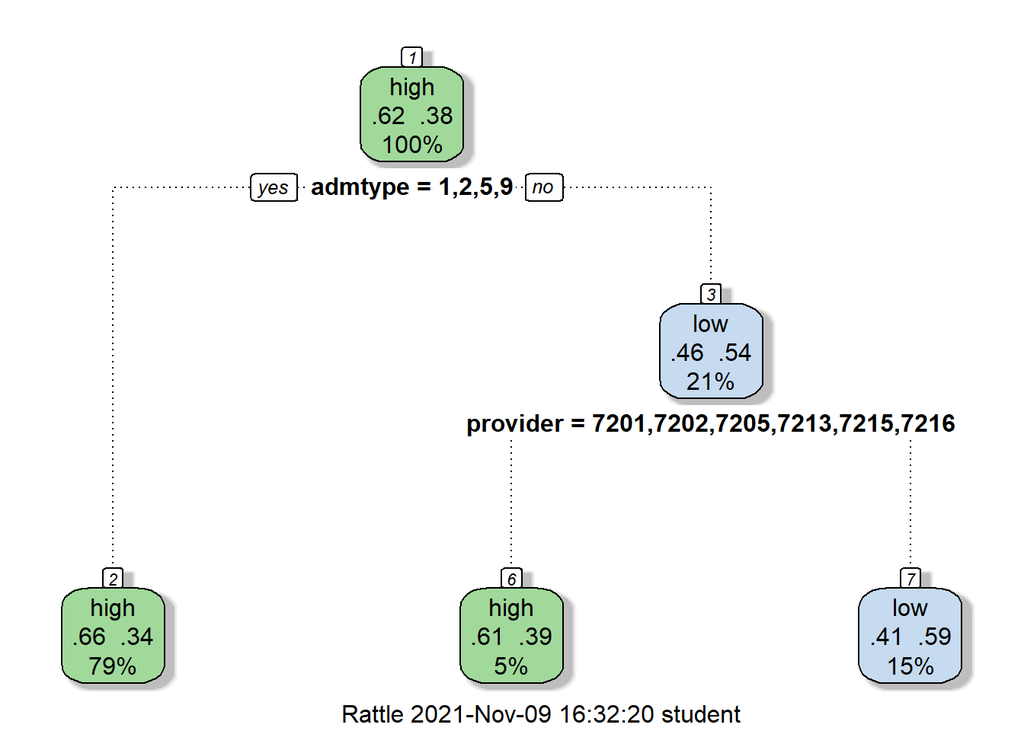

```r
df3$targetB <- case_when(
  df3$los < 3 ~ 'low',
  df3$los >= 3 ~'high',
  TRUE ~ 'high')

df3$targetB <- as.factor(df3$targetB)
df3B <- select(df3,-c('los','target'))

#back to using full data set
library(caret)
set.seed(2020)
splitIndex <- createDataPartition(df3B$targetB, p = .90,
                                  list = FALSE)
df3_train <- df3B[ splitIndex,]
df3_test <- df3B[-splitIndex,]

library(rpart)
set.seed(2020)
tree_model <- rpart(targetB ~ ., data = df3_train,
                 control = rpart.control(maxdepth = 4))

# Plot the results
library(rattle)
fancyRpartPlot(tree_model)
```

The first split for the model has to deal with `admittance type`: if a patient is admitted for an emergency, urgent, trauma, or unknown reason, the patient is likely to stay for 3 days or longer. The other split shown above has to deal with which hospital (`provider`) a patient is at.

```r
tree_model$variable.importance
```

```
##    admtype   provider        age     campus   raceethn
## 1562.92268  510.13810  500.23618  245.07849   13.52029
```

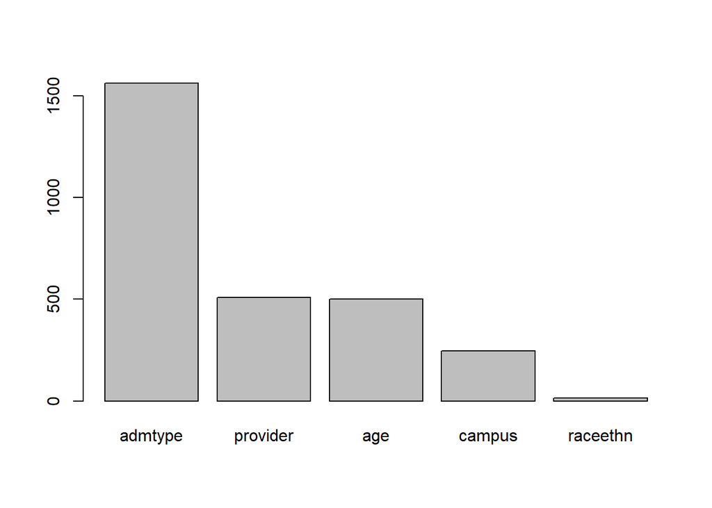

```r
barplot(tree_model$variable.importance)
```

The most important variable in determining if a patient will stay longer than two days is the `reason for admittance`, which makes sense from above. The next most important variables are `provider` and `age`. Maybe people go to different hospitals for major issues than for quick concerns, and it is possible that age has an impact both on why patients go to the hospital and how quickly they may recover.

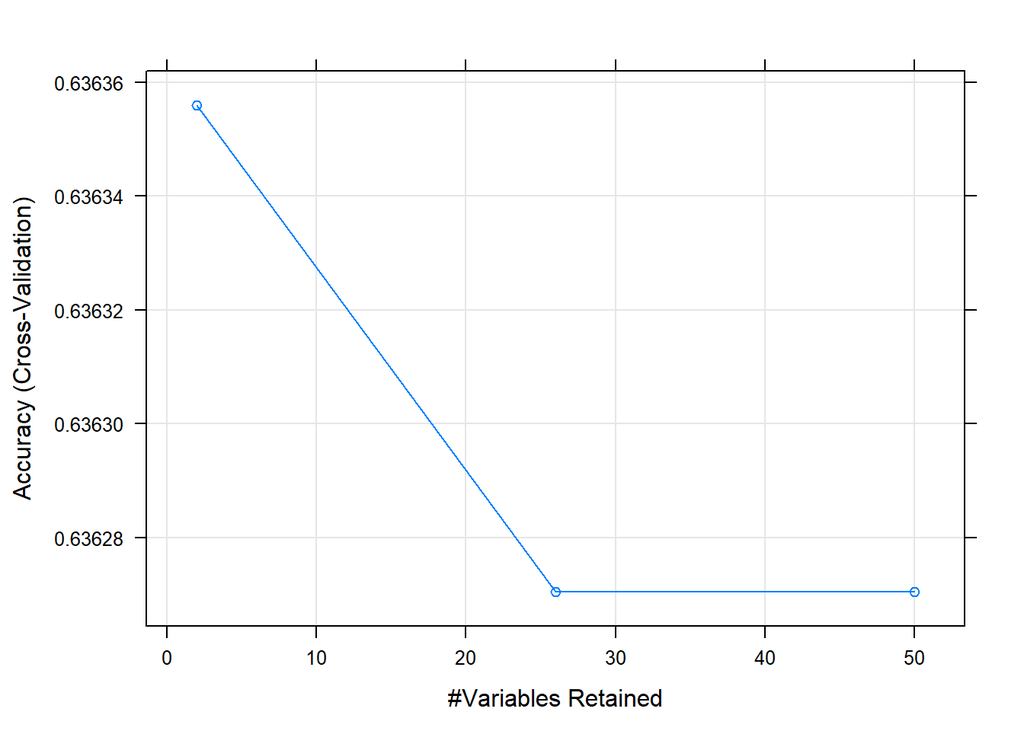

```r
set.seed(2020)
df3Bsmall <- sample_n(df3B,13000)
library(caret)
set.seed(2020)
splitIndex <- createDataPartition(df3Bsmall$targetB, p = .90,
                                  list = FALSE)
df3_train <- df3Bsmall[ splitIndex,]
df3_test <- df3Bsmall[-splitIndex,]

trControl = trainControl(method = "cv",
                         number = 5)

model1 <- train(targetB~., data=df3_train,
                                method = "rocc",
                                trControl = trControl)
plot(model1)
```